# Prunedale Elementary Dashboard Summary

## Report Purpose

This report is created to assist Prunedale Elementary in reflecting on the student groups whose indicators led to Differentiated Assistance for North Monterey County Unified.

## Qualifying Groups

Differentiated Assistance is determined by the California Dashboard. Colors reflect the latest available status from 2022. For all graphs, the darker the color the lower the status.

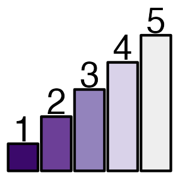

The graphic below shows the color for each student group for each indicator from the California 2022 Dashboard.

[California Dashboard 2022](https://www.caschooldashboard.org/reports/27738250000000/2022)

The graph below displays which student groups qualified North Monterey County Unified to be eligible for [Differentiated Assistance](https://www.cde.ca.gov/ta/ac/cm/leaproposedcrit.asp). Moreover, for each student group it shows which Priority Areas and associated indicators met qualification criteria.

As a reminder, COEs must offer differentiated assistance to a school district if any student group meets the criteria for two or more LCFF priorities according to California Education Code Section 52071(c). [California’s System of Support](https://www.cde.ca.gov/sp/sw/t1/csss.asp)

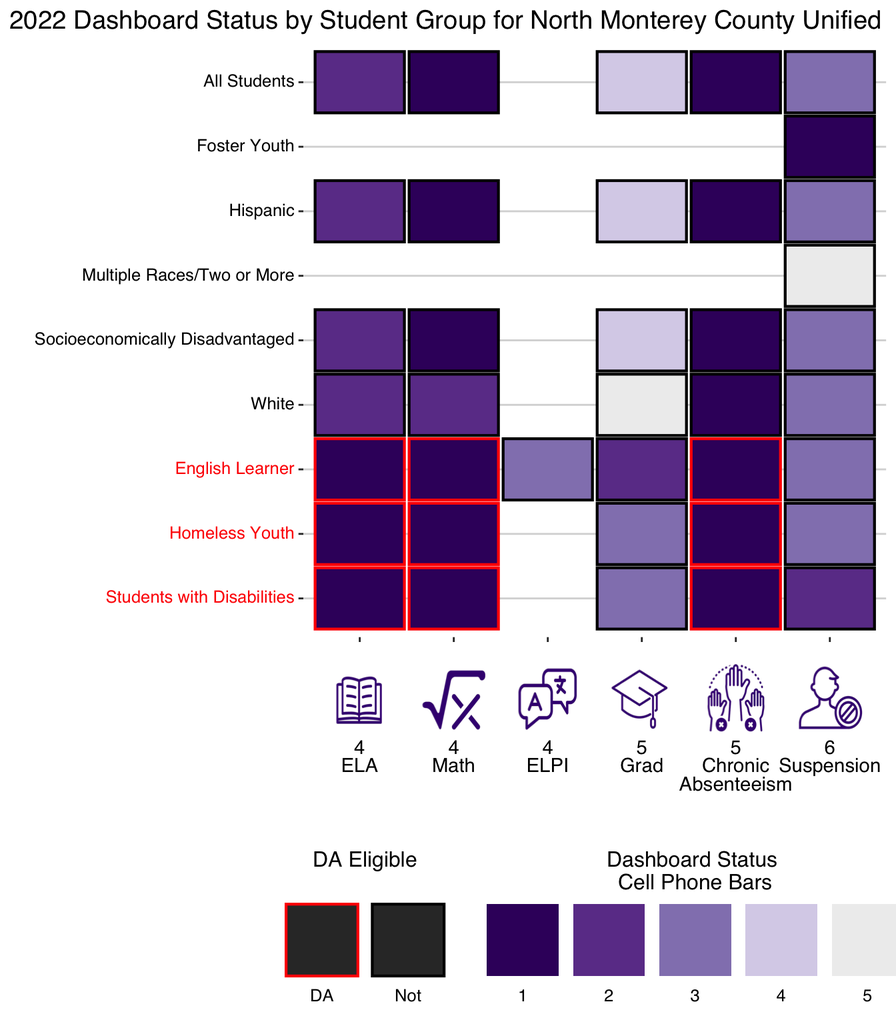

For Prunedale Elementary, the below graph shows how at the school level their student groups did at the school level which contributed to North Monterey County Unified as an LEA overall.

Note this graph also includes student groups with 11 to 29 students in them to provide a fuller picture even if those groups are not used for state accountability calculations such as CSI/ATSI.

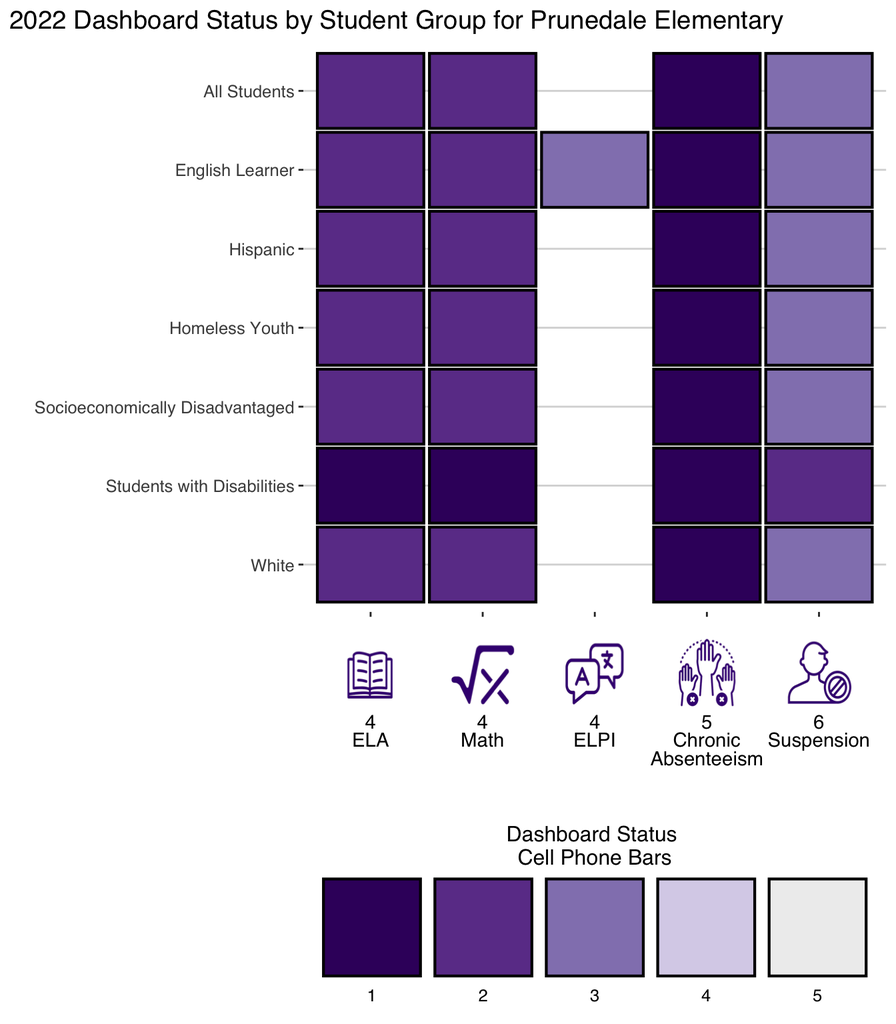

## CSI/ATSI Designations

Under ESSA, schools can be identified for Comprehensive Support and Improvement (CSI) or Additional Targeted Support and Improvement (ATSI). CSI is based on a school’s overall or All Students indicators, whereas ATSI is based on each student group’s indicators. For more information please see: [CDE School Support](https://www.cde.ca.gov/sp/sw/t1/schoolsupport.asp). It is important to note that calculations are only based on student groups with 30 or more students, which means not all the indicators on the previous graph will be used.

This school is not eligible for CSI.

| School | Student Group | Reason for ATSI | ELA Status | Math Status | ELPI Status | Chronic Absenteeism Status | Graduation Status | Suspension Status |
| --- | --- | --- | --- | --- | --- | --- | --- | --- |
| Prunedale Elementary | Students with Disabilities | All but one Indicator at Lowest Status |  |  |  | 1 |  | 2 |

## Status Details for all Indicators

These graphs represent all of the indicators from the Dashboard and show how each of the student groups performed.

**Click here to display graphs**

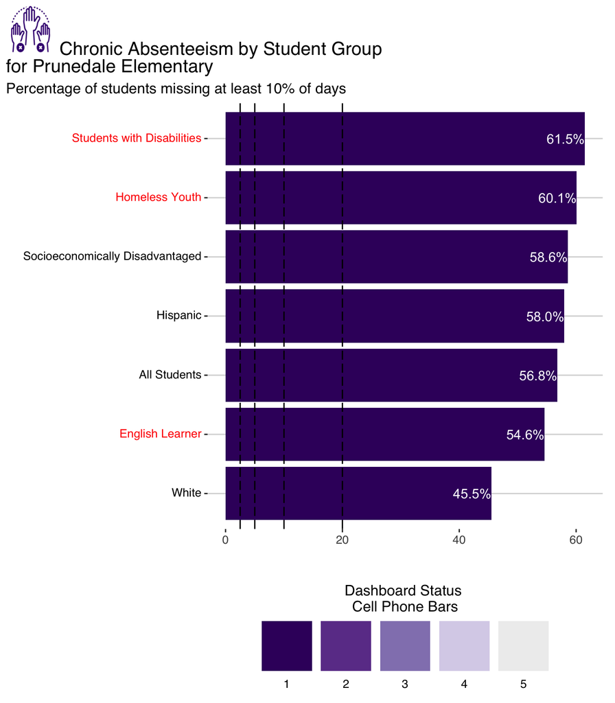

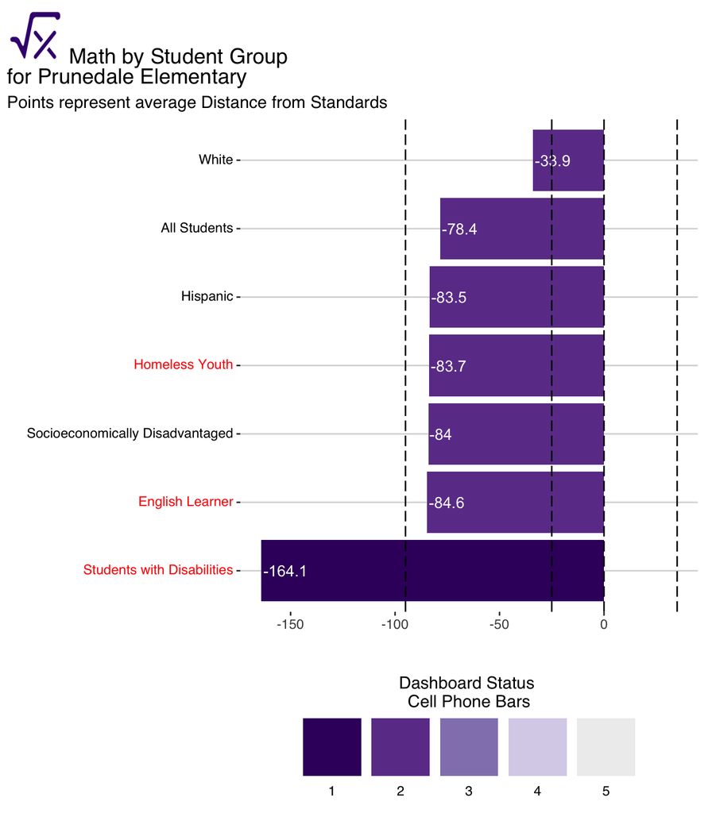

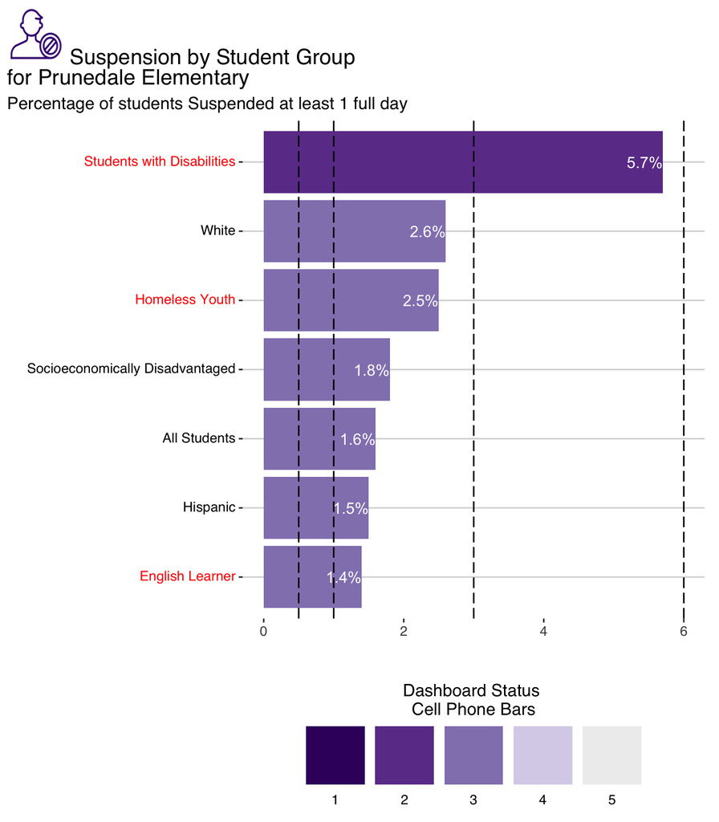

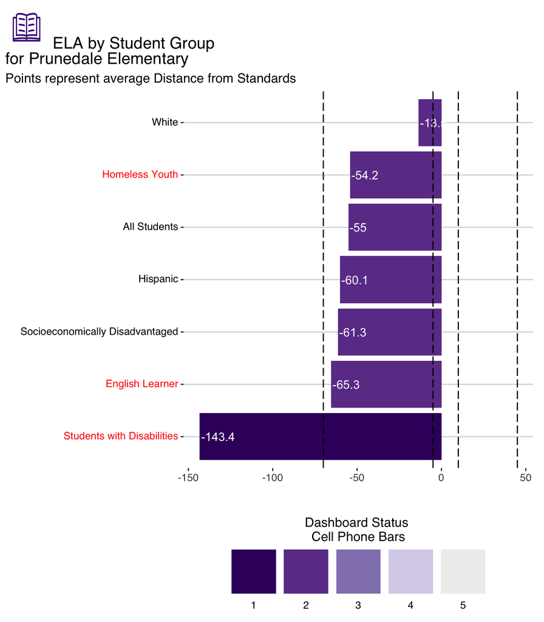

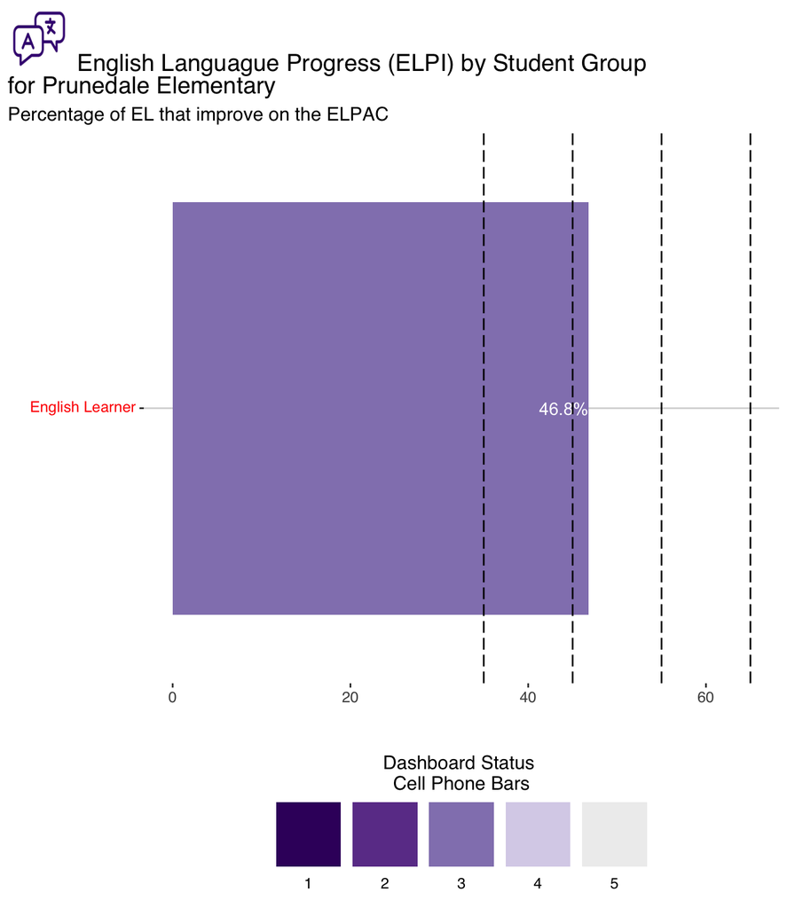

## Historical Graphs for Eligible Groups

These graphs represent all of the indicators from Priority Areas that qualified the district for DA or school for ATSI. They included all DA qualifying student groups and student groups qualify for ATSI on each graph, whether this was a qualifying indicator or not. In addition, the All Students group is included in all graphs for comparisons.

**Click here to display graphs**

[figure not shown]

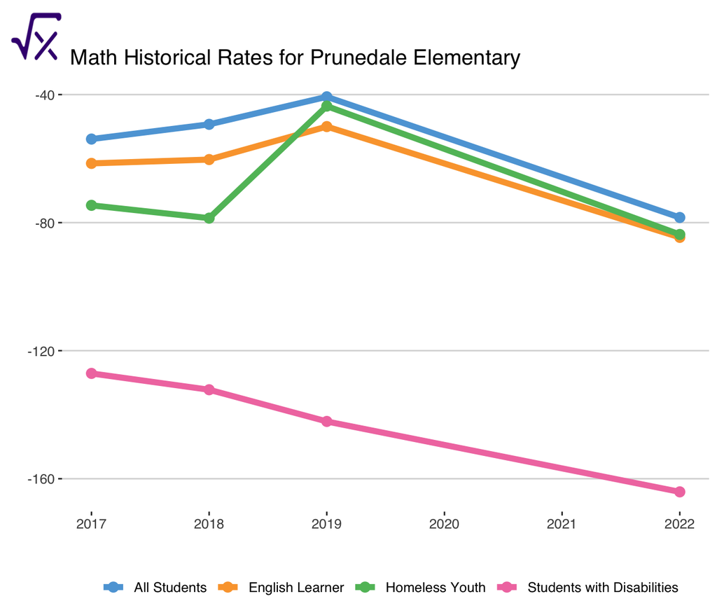

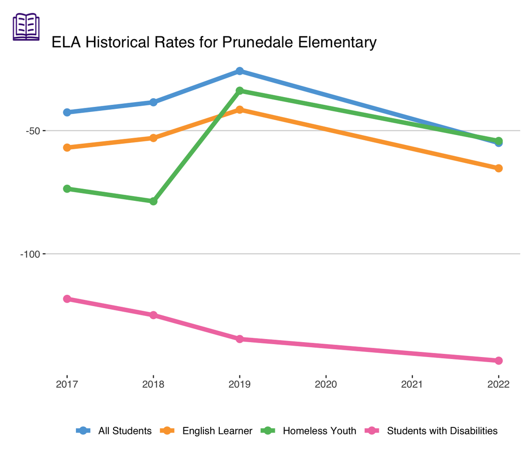

## Status Needed to Avoid Red in 2023

This section estimates the limits for indicators to receive an orange or higher color next year on the 2023 Dashboard. The thresholds below are based on the [5x5 grids last approved by the State Board of Education](https://www.cde.ca.gov/ta/ac/cm/fivebyfivecolortables19.asp#AcademicTable) and the number of students in the 2022 calculation. State policies may change and the student counts may shift. Only student groups in DA and their qualifying indicators for North Monterey County Unified are included below and only if they are in the lowest status for Prunedale Elementary. The thresholds represent the numbers for Prunedale Elementary.

| Student Group | Indicator | Current Status | Target Status for Orange | Change Needed | Number of Students (as applicable) |
| --- | --- | --- | --- | --- | --- |
| English Learner | chronic | 54.6 | 54.1 | -0.5 | 195 |
| Homeless Youth | chronic | 60.1 | 59.6 | -0.5 | 94 |
| Students with Disabilities | chronic | 61.5 | 61 | -0.5 | 31 |

The following sentences convey the same information as the table above in a different format for those who prefer written statements.

**Click here to display sentences**

[1] “*English Learner* student group should have 195 or less students **chroncially absent** based on the count in 2022 of 361 to not be in Red.”  
[2] “*Homeless Youth* student group should have 94 or less students **chroncially absent** based on the count in 2022 of 158 to not be in Red.”  
[3] “*Students with Disabilities* student group should have 31 or less students **chroncially absent** based on the count in 2022 of 52 to not be in Red.”

This report was last updated at 2023-02-22 09:46:57.

It was developed by [David Dobrowski](https://github.com/dobrowski) at the [Monterey County Office of Education](https://www.montereycoe.org/)

[figure not shown]